# Chapter 6 Summary: Forecasting with MA Processes

## SETUP

```r
#setwd("/Users/anjali/Documents/university/Econ_5305/code_directory/Chapter6")
rm(list = ls())
```

```r
library(openxlsx)
library(readxl)
library(ggplot2)
library(dynlm)
library(forecast)
```

## QUESTION 1

#### Part a: Give example of an economic Time series that behaves like white noise process:

A white noise process is characterized by auto correlations and partial autocorrelation functions that are equal to zero. Some examples of time series that behave like white noise are stock prices. Indexes like the NASDAQ, DOW, etc. behave like white noise time series that are random and have almost zero ACF and PACF.

#### Part b: Generate 100 observations from a white noise process

```r
# Generate the white noise process
set.seed(42) # set seed for reproducibility
white_noise <- arima.sim(model = list(order = c(0, 0, 0)), n = 100, mean=0, sd=4)
```

```r
# summary of the white noise process
summary(white_noise)
```

```
##     Min.  1st Qu.   Median     Mean  3rd Qu.     Max.
## -11.9724  -2.4668   0.3592   0.1301   2.6462   9.1466
```

```r
cat( "Standard deviation for white noise process ", sd(white_noise))
```

```
## Standard deviation for white noise process  4.165428
```

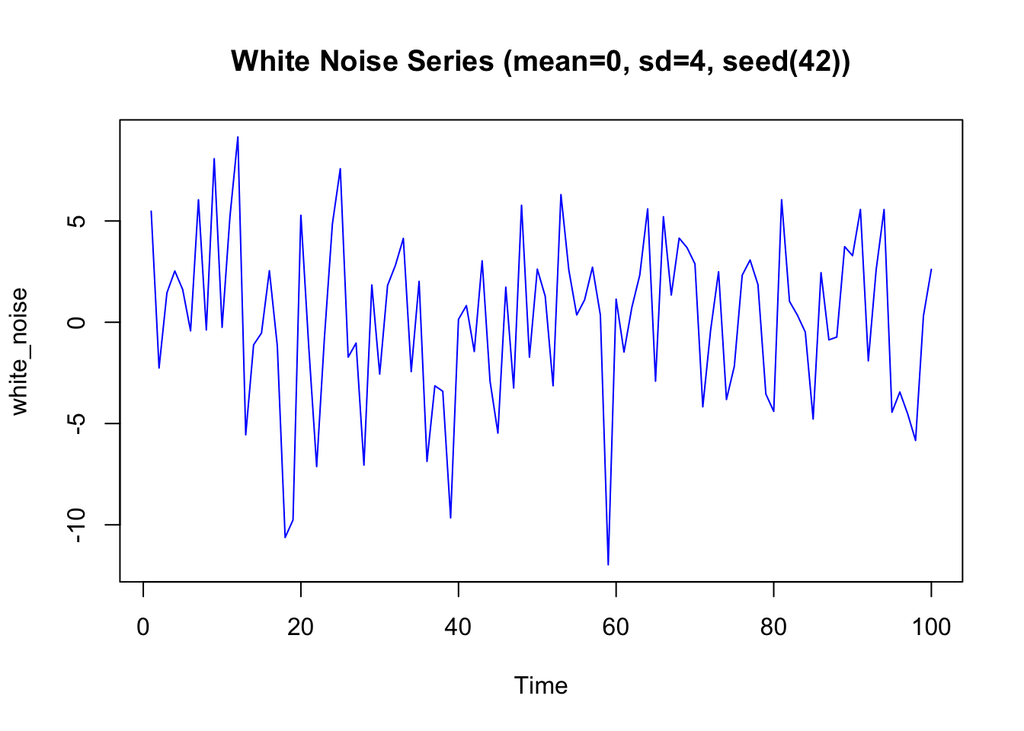

```r
# plot time series for the white noise process
plot.ts(white_noise,col="blue", main="White Noise Series (mean=0, sd=4, seed(42))")
```

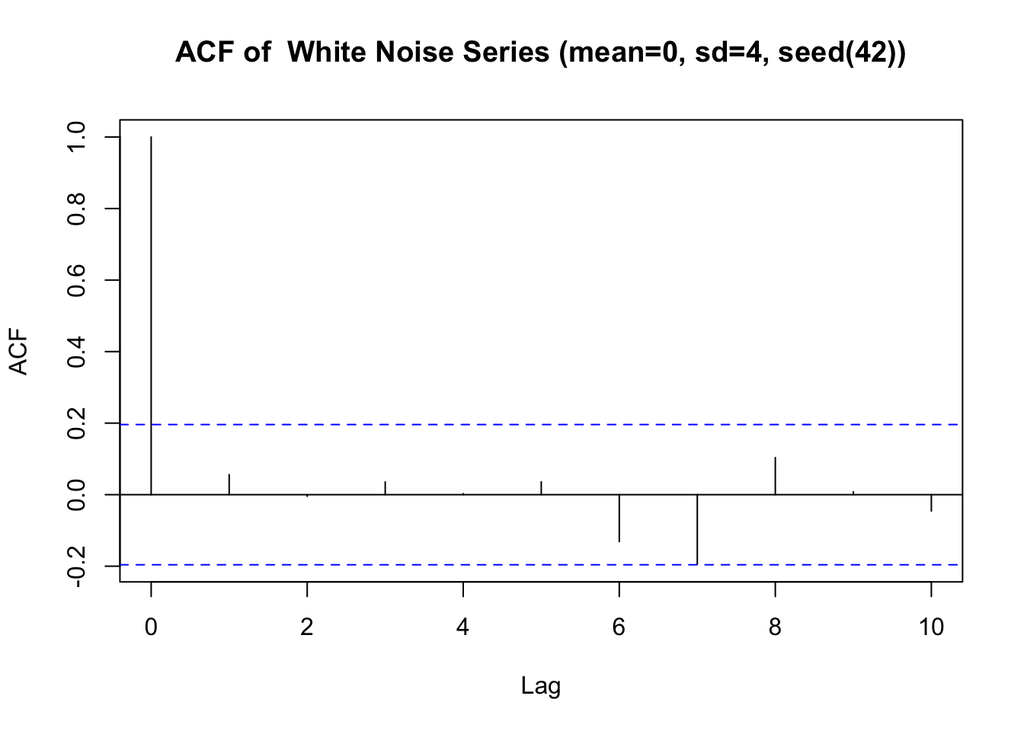

```r
# plot ACF for white noise process
acf(white_noise,lag.max= 10, plot = TRUE, main = "ACF of  White Noise Series (mean=0, sd=4, seed(42))")
```

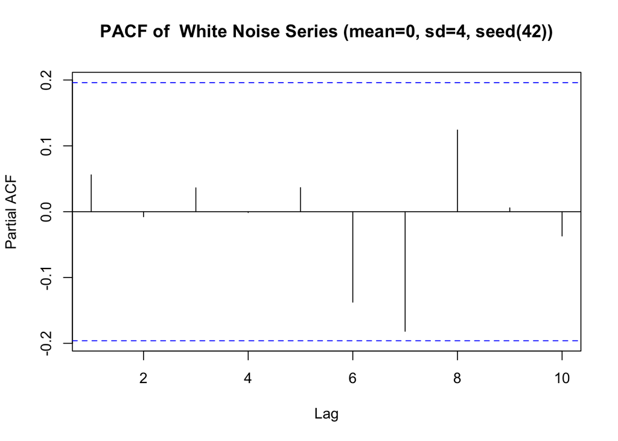

```r
pacf(white_noise,lag.max= 10, plot = TRUE, main = "PACF of  White Noise Series (mean=0, sd=4, seed(42))")
```

**Interpretation of Behavior:** We see that the Auto correlation functions for the White noise time series is very low close to zero and oscillates between +0.2 and -0.2.

#### Part c: Working with stock indexes

```r
excel_sheets("ch6_q1_stock_index.xlsx")
```

```
## [1] "NDX"     "DJIA"    "DJT"     "Details"
```

```r
data_1a <- read_excel("ch6_q1_stock_index.xlsx", sheet ="NDX")
data_1b <- read_excel("ch6_q1_stock_index.xlsx", sheet ="DJIA")
data_1c <- read_excel("ch6_q1_stock_index.xlsx", sheet ="DJT")
```

```r
# read the time series for the three indexes
T_NDX<-ts(data_1a$Close,frequency=365,start=c(2008,12,31))
T_DJIA <-ts(data_1b$Close,frequency=365,start=c(2004,2,1))
T_DJT <-ts(data_1c$Close,frequency=365,start=c(2004,2,1))

# calculate growth rates by taking the difference of the log (natural log)
NDX <- 100*diff(log(T_NDX))
DJIA <- 100*diff(log(T_DJIA))
DJT <- 100*diff(log(T_DJT))
```

```r
# NASDAQ index
cat("NASDAQ Index Growth Descriptive Statistics:\n")
```

```
## NASDAQ Index Growth Descriptive Statistics:
```

```r
summary(NDX)
```

```
##     Min.  1st Qu.   Median     Mean  3rd Qu.     Max.
## -9.59664 -0.73874 -0.11738 -0.06623  0.49080 13.00315
```

```r
cat("Standard deviation: ", sd(NDX))
```

```
## Standard deviation:  1.353825
```

```r
# Dow Jones Industrial Average Index Growth
cat("\n\nDow Jones Industrial Average Index Growth Descriptive Statistics:\n")
```

```
##
##
## Dow Jones Industrial Average Index Growth Descriptive Statistics:
```

```r
summary(DJIA)
```

```
##      Min.   1st Qu.    Median      Mean   3rd Qu.      Max.
## -10.76432  -0.53879  -0.05348  -0.02410   0.41815  13.84181
```

```r
cat("Standard deviation: ", sd(DJIA))
```

```
## Standard deviation:  1.158103
```

```r
# NASDAQ index
cat("\n\nDow Jones Transport Average Index Growth Descriptive Statistics:\n")
```

```
##
##
## Dow Jones Transport Average Index Growth Descriptive Statistics:
```

```r
summary(DJT)
```

```
##      Min.   1st Qu.    Median      Mean   3rd Qu.      Max.
## -11.76791  -0.84484  -0.08127  -0.03166   0.71840  12.25846
```

```r
cat("Standard deviation: ", sd(DJT))
```

```
## Standard deviation:  1.548152
```

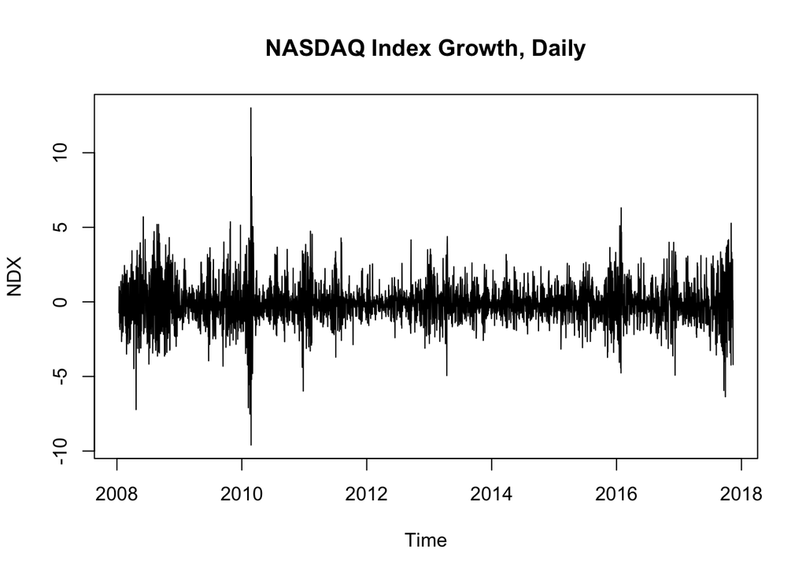

```r
plot(NDX, main="NASDAQ Index Growth, Daily")
```

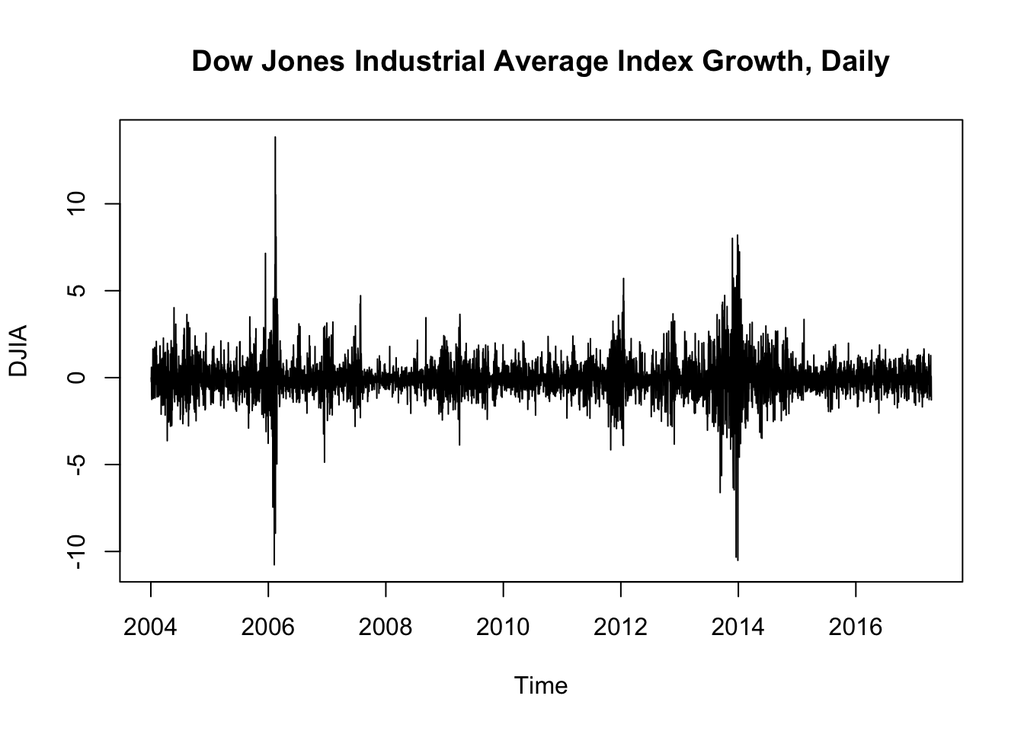

```r
plot(DJIA, main="Dow Jones Industrial Average Index Growth, Daily")
```

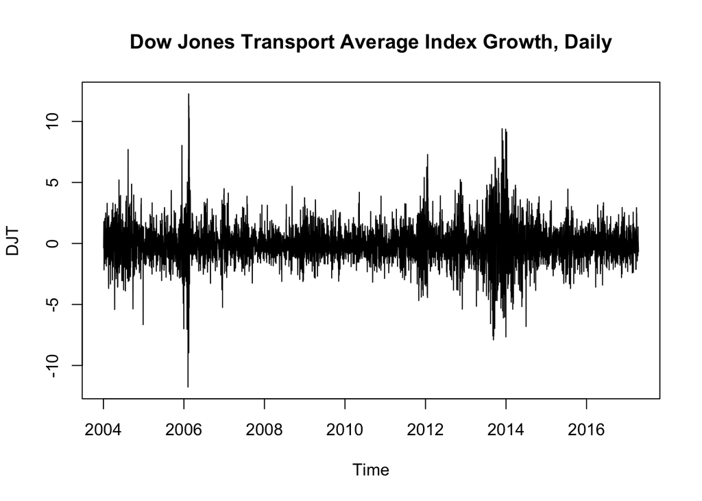

```r
plot(DJT, main="Dow Jones Transport Average Index Growth, Daily")
```

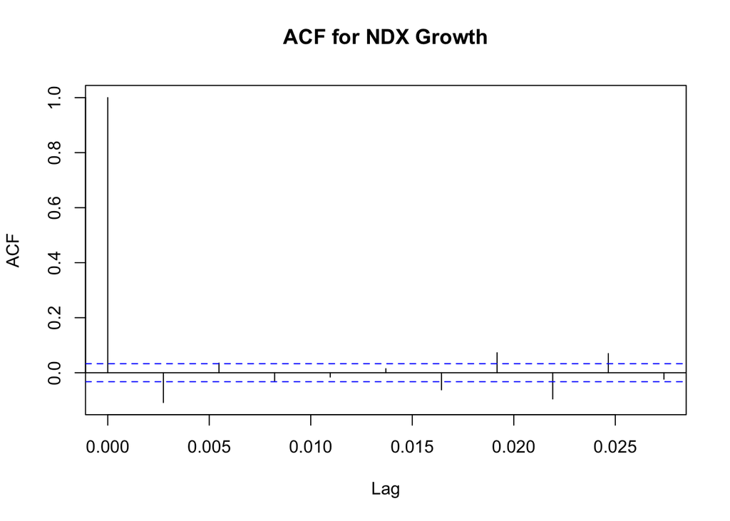

```r
acf(NDX,lag.max= 10, plot = TRUE, main = "ACF for NDX Growth")
```

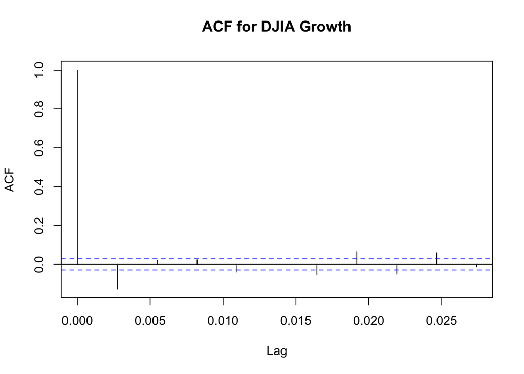

```r
acf(DJIA,lag.max= 10, plot = TRUE, main = "ACF for DJIA Growth")
```

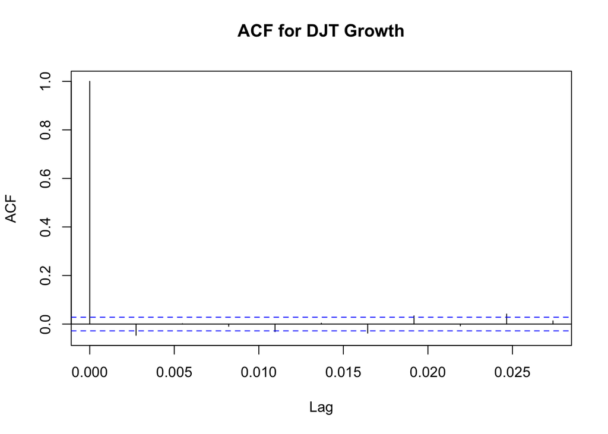

```r
acf(DJT,lag.max= 10, plot = TRUE, main = "ACF for DJT Growth")
```

**Interpretation:**

- For NDX we see that there is a small -ve spike r1, however there is a similar spike at 8th period. Although this this is very close to white noise we might be able to use MA(1) process to model the NDX returns.
- For DJIA index we see that there is a similar -ve spike at r1 and other spikes are much smaller. MA(1) process can be used to try to model this process
- For DJT again has a very small spike at lag one but there are similar spikes athe 6th,7th,9th lags. This looks least promising to be modeled as an MA(1) process and looks very similar to white noise

#### Models

```r
model_ndx<-arima(x=NDX,order=c(0,0,1))
model_ndx
```

```
##
## Call:
## arima(x = NDX, order = c(0, 0, 1))
##
## Coefficients:
##           ma1  intercept
##       -0.1035    -0.0662
## s.e.   0.0162     0.0201
##
## sigma^2 estimated as 1.812:  log likelihood = -6160.85,  aic = 12327.69
```

```r
forecast(model_ndx,h=4)
```

```
##           Point Forecast     Lo 80    Hi 80     Lo 95    Hi 95
## 2017.8685     0.36126085 -1.363770 2.086291 -2.276946 2.999467
## 2017.8712    -0.06621939 -1.800468 1.668029 -2.718523 2.586085
## 2017.8740    -0.06621939 -1.800468 1.668029 -2.718523 2.586085
## 2017.8767    -0.06621939 -1.800468 1.668029 -2.718523 2.586085
```

```r
model_djia<-arima(x=DJIA,order=c(0,0,1))
model_djia
```

```
##
## Call:
## arima(x = DJIA, order = c(0, 0, 1))
##
## Coefficients:
##           ma1  intercept
##       -0.1224    -0.0241
## s.e.   0.0139     0.0145
##
## sigma^2 estimated as 1.32:  log likelihood = -7552.28,  aic = 15110.57
```

```r
forecast(model_djia,h=4)
```

```
##           Point Forecast     Lo 80    Hi 80     Lo 95   Hi 95
## 2017.2877     0.12852225 -1.343954 1.600998 -2.123436 2.38048
## 2017.2904    -0.02409564 -1.507562 1.459371 -2.292861 2.24467
## 2017.2932    -0.02409564 -1.507562 1.459371 -2.292861 2.24467
## 2017.2959    -0.02409564 -1.507562 1.459371 -2.292861 2.24467
```

```r
model_djt<-arima(x=DJT,order=c(0,0,1))
model_djt
```

```
##
## Call:
## arima(x = DJT, order = c(0, 0, 1))
##
## Coefficients:
##           ma1  intercept
##       -0.0464    -0.0317
## s.e.   0.0143     0.0212
##
## sigma^2 estimated as 2.391:  log likelihood = -8995.88,  aic = 17997.75
```

```r
forecast(model_djt,h=4)
```

```
##           Point Forecast     Lo 80    Hi 80     Lo 95    Hi 95
## 2017.2932   -0.001117901 -1.982813 1.980578 -3.031859 3.029624
## 2017.2959   -0.031655677 -2.015484 1.952173 -3.065660 3.002349
## 2017.2986   -0.031655677 -2.015484 1.952173 -3.065660 3.002349
## 2017.3014   -0.031655677 -2.015484 1.952173 -3.065660 3.002349
```

**Interpretations of the model:** The forecasts can be done for only 1 period (1 day ahead) as we are using MA(1). Beyond 1 day the forecast for the model reverts to the unconditional mean. The models are not very good as the AIC values are very high.

## QUESTION 2

```r
data_2 <- read_excel("ch6_q7_q8_treasury_yields.xls")
View(data_2)

# read the time series for 5-year constant maturity
T_TCM5Y<-ts(data_2$GS5,frequency=12,start=c(1953,4,1), end =c(2023,3,1))
```

```r
cat("5-Year Treasury note yield (%):\n")
```

```
## 5-Year Treasury note yield (%):
```

```r
summary(T_TCM5Y)
```

```
##    Min. 1st Qu.  Median    Mean 3rd Qu.    Max.
##   0.270   2.888   4.825   5.281   7.088  15.930
```

```r
cat("Standard deviation: ", sd(T_TCM5Y))
```

```
## Standard deviation:  3.087518
```

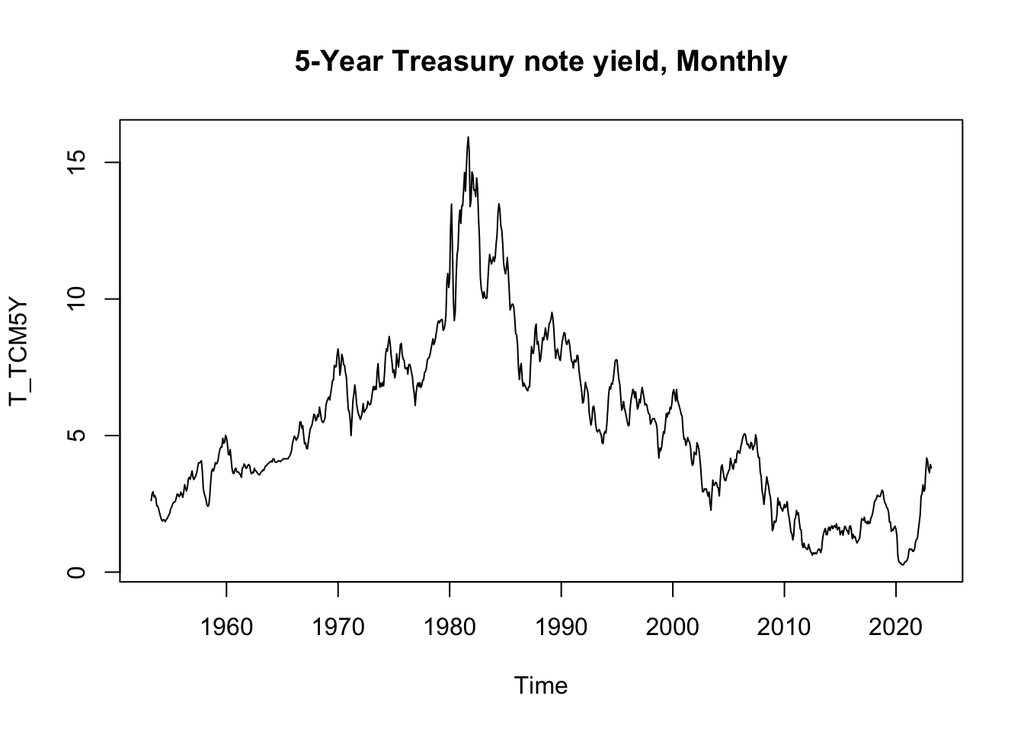

```r
plot.ts(T_TCM5Y, main="5-Year Treasury note yield, Monthly")
```

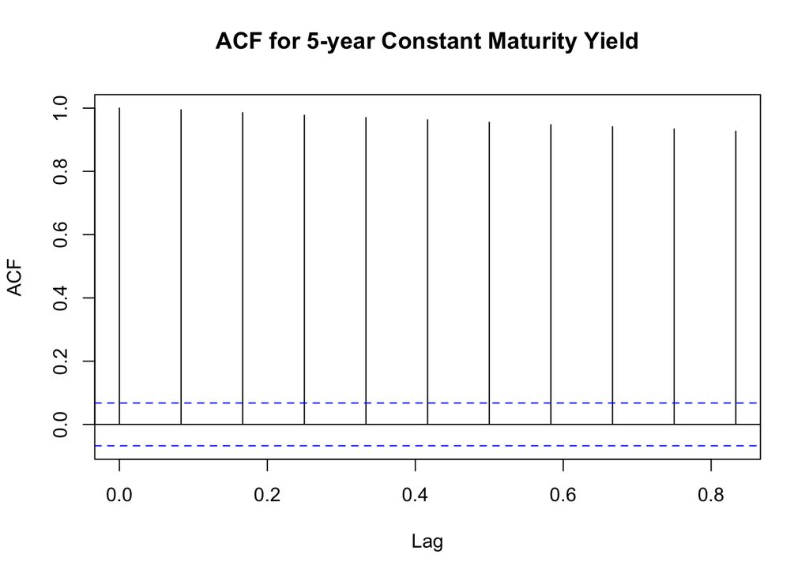

```r
acf(T_TCM5Y,lag.max= 10, plot = TRUE, main = "ACF for 5-year Constant Maturity Yield")
```

**Key Findings:**

- This time-series is not stationary (mean is not constant) since values do not oscillate around the mean (5.281%).
- Based on all the ACF graphs and outputs, all lags have statistically significant positive correlations. From the graphs we can also observe that trends are present in the time series with shorter lags exhibiting larger positive correlations. Hence in these auto-correlations - for all treasury yields - decline slowly with all lags being significant.
- Plotting the time series and ACF confirms the assumption of the presence of trends.**
- We should do some transformations on the series in order that it is stationary. Similar to Fig 6.5 in the textbook we should calculate the growth of change in the 5-year Treasury note yield (%).

```r
# calculate growth rates by taking the difference of the log (natural log)
TCM5Y <- 100*diff(log(T_TCM5Y))
```

```r
cat("Change in the 5-Year Treasury note yield - Descriptive Statistics:\n")
```

```
## Change in the 5-Year Treasury note yield - Descriptive Statistics:
```

```r
summary(TCM5Y)
```

```
##      Min.   1st Qu.    Median      Mean   3rd Qu.      Max.
## -80.52645  -3.45223   0.00000   0.04494   3.32443  41.77352
```

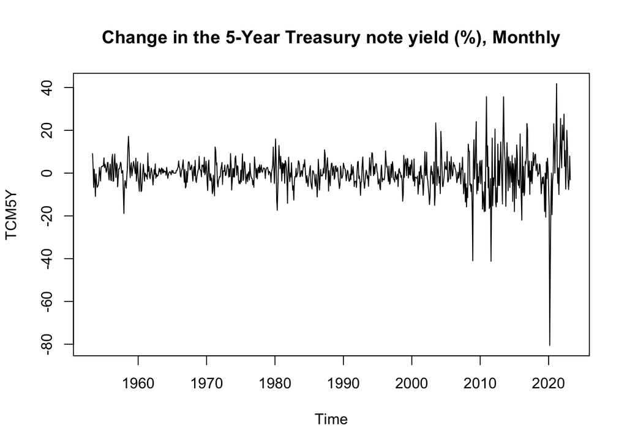

```r
plot.ts(TCM5Y, main="Change in the 5-Year Treasury note yield (%), Monthly")
```

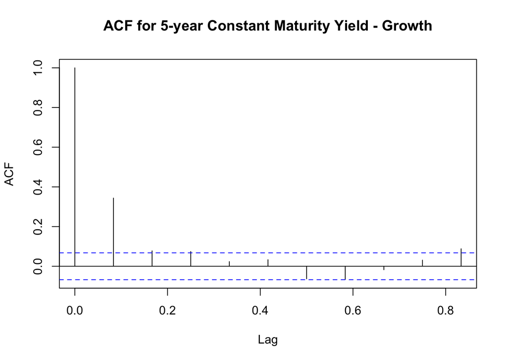

```r
acf(TCM5Y,lag.max= 10, plot = TRUE, main = "ACF for 5-year Constant Maturity Yield - Growth")
```

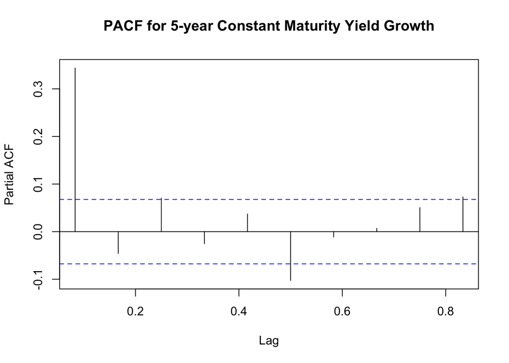

```r
pacf(TCM5Y,lag.max= 10, plot = TRUE, main = "PACF for 5-year Constant Maturity Yield Growth")
```

**Key Findings:** Looking at the growth series we see that it is second order weakly stationary. The 1 single spike in the ACF indicates that we can propose an MA(1) process and estimate a model.

```r
model_tcm5y<-arima(x=TCM5Y,order=c(0,0,1))
model_tcm5y
```

```
##
## Call:
## arima(x = TCM5Y, order = c(0, 0, 1))
##
## Coefficients:
##          ma1  intercept
##       0.3599     0.0455
## s.e.  0.0325     0.3425
##
## sigma^2 estimated as 53.25:  log likelihood = -2858.05,  aic = 5722.1
```

```r
forecast(model_tcm5y,h=3)
```

```
##          Point Forecast      Lo 80    Hi 80     Lo 95    Hi 95
## Apr 2023     -2.1586230 -11.510194 7.192948 -16.46062 12.14337
## May 2023      0.0455216  -9.893377 9.984420 -15.15471 15.24575
## Jun 2023      0.0455216  -9.893377 9.984420 -15.15471 15.24575
```

**Interpretations:**

- The moving average cannot forecast longer future, and as the horizon goes up, the point forecast as well as the intervals start to be stable without change. In this case as the process is MA(1) after the first forecast it reverts to unconditional mean.
- The has an aic = 5722.1
- Similarities to section 6.3.1: The acf pattern for the growth series is similar which shows that the nature of the 5-year constant maturity yield has not changed
- The differences are in volatility. we can see that by updating the data there are more periods of high volatility. Because now we are including both the 2008 recession and 2020 covid-19 crisis.

## QUESTION 3

```r
# read the time series for 5-year constant maturity
# set periods to where all series have data so no N/A occurs
T_5Y<-ts(data_2$GS5,frequency=12,start=c(1962,1,1), end =c(2023,3,1)) # 5year
T_10Y<-ts(data_2$DGS10,frequency=12,start=c(1962,1,1), end =c(2023,3,1)) # 10 year
T_1Y<-ts(data_2$DGS1,frequency=12,start=c(1962,1,1), end =c(2023,3,1)) # 1 year
#T_3Y<-ts(data_2$DGS3,frequency=12,start=c(1962,1,1), end =c(2023,3,1)) # 3 year (not considering for simpler analysis 1 higher and 1 lower should suffice)
```

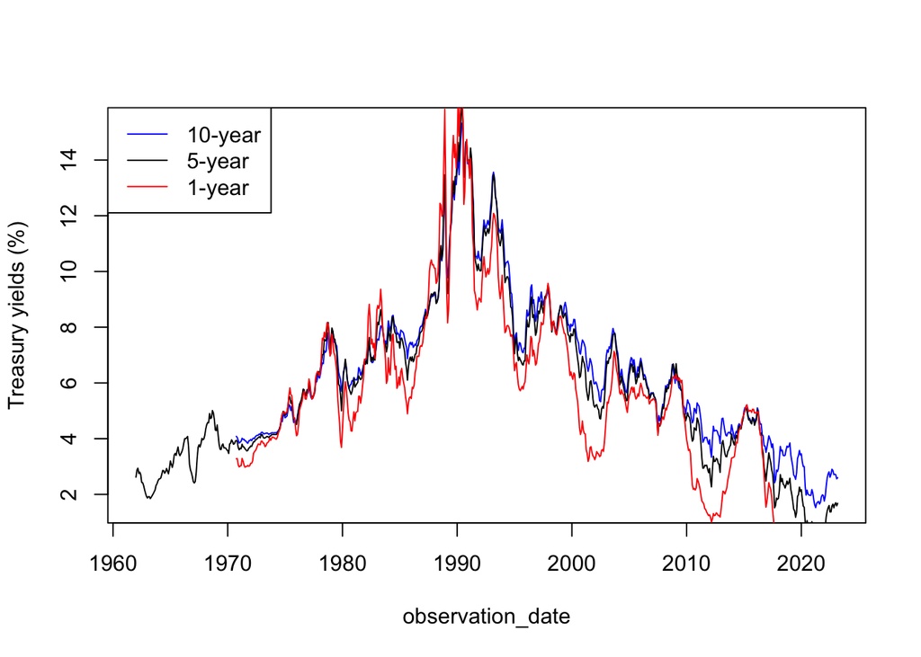

```r
# Line plot
plot(T_10Y, type ='l',col = "blue" , xlab= "observation_date", ylab = "Treasury yields (%)")
lines(T_5Y, type = 'l', col = "black")
lines(T_1Y, type = 'l', col = "red")
legend("topleft", c("10-year","5-year","1-year") ,lty = 1, col = c("blue","black","red"))
```

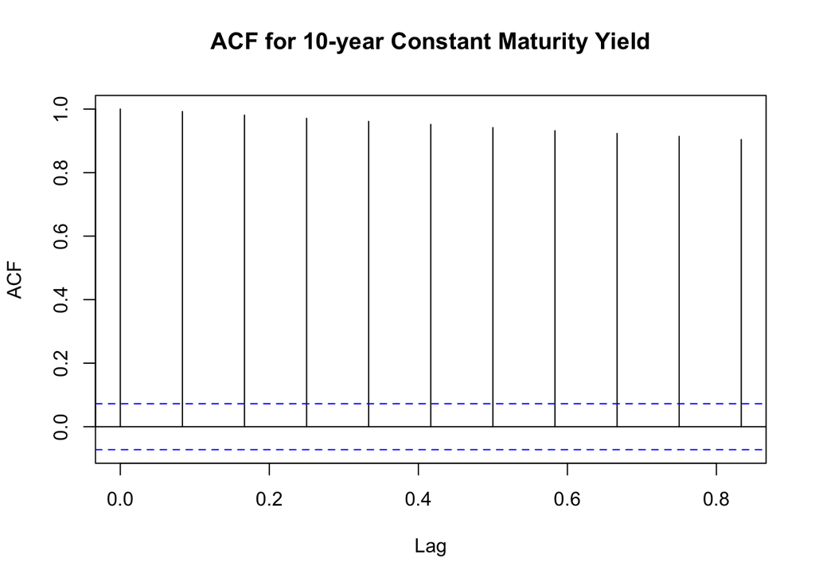

```r
# ACF plots
acf(T_10Y,lag.max= 10, plot = TRUE, main = "ACF for 10-year Constant Maturity Yield",na.action = na.pass)
```

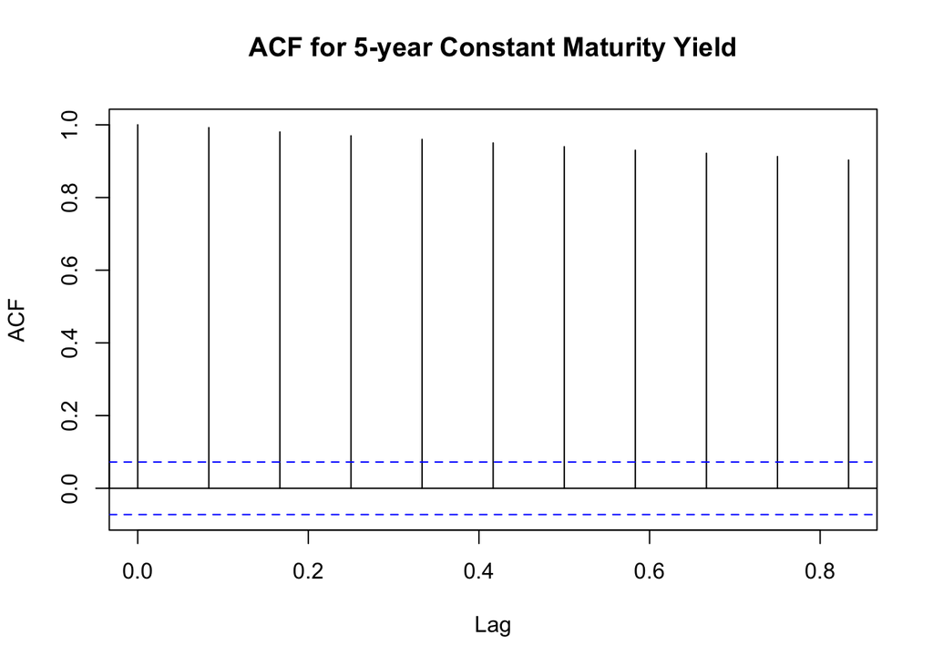

```r
acf(T_5Y,lag.max= 10, plot = TRUE, main = "ACF for 5-year Constant Maturity Yield",na.action = na.pass)
```

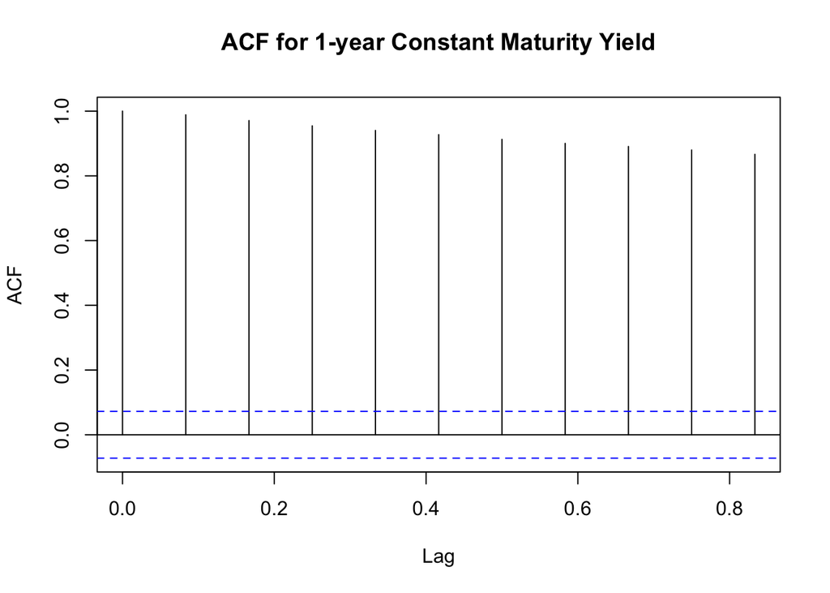

```r
acf(T_1Y,lag.max= 10, plot = TRUE, main = "ACF for 1-year Constant Maturity Yield",na.action = na.pass)
```

**Key Findings**: As in previous question we see very high autocorrelation indicating that the graph has trends . This suggests that adjacent values of the time series are strongly correlated and indicates that if the value of the time series is high at a given point then the value will be high at the adjacent time point. We can also see that the autocorrelation values fall slightly more steeply for 1-year period this occurs because 1-year are more short-term in nature as compared to 10-year maturity?

```r
# calculate growth rates by taking the difference of the log (natural log)
yield_growth_10Y <- 100*diff(log(T_10Y))
yield_growth_5Y <- 100*diff(log(T_5Y))
yield_growth_1Y <- 100*diff(log(T_1Y))
```

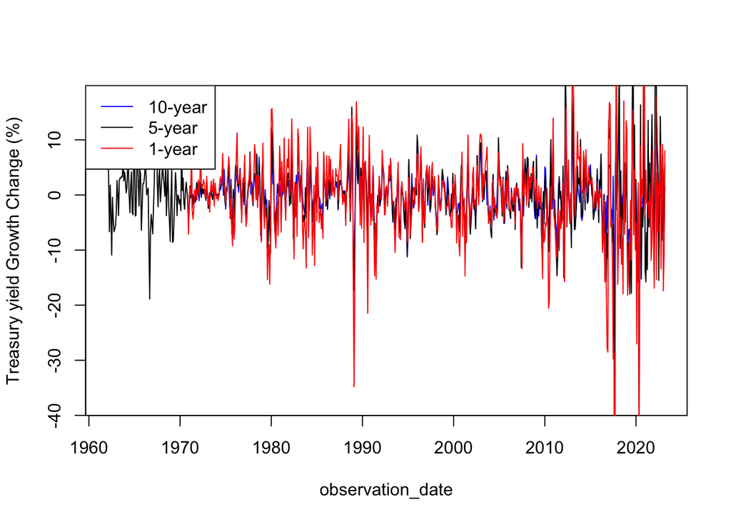

```r
# Line plot
plot(yield_growth_10Y, type ='l',col = "blue" , xlab= "observation_date", ylab = "Treasury yield Growth Change (%)")
lines(yield_growth_5Y, type = 'l', col = "black")
lines(yield_growth_1Y, type = 'l', col = "red")
legend("topleft", c("10-year","5-year","1-year") ,lty = 1, col = c("blue","black","red"))
```

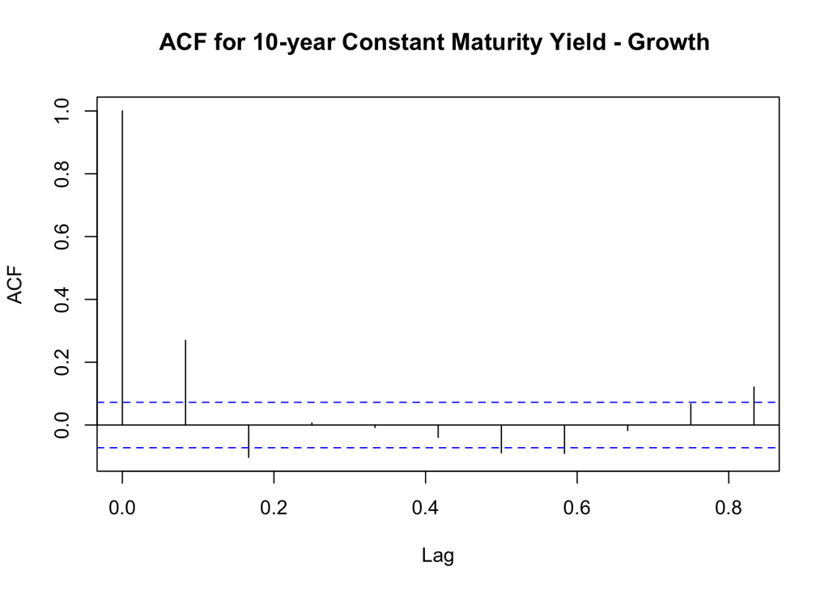

```r
# ACF plots
acf(yield_growth_10Y,lag.max= 10, plot = TRUE, main = "ACF for 10-year Constant Maturity Yield - Growth ",na.action = na.pass)
```

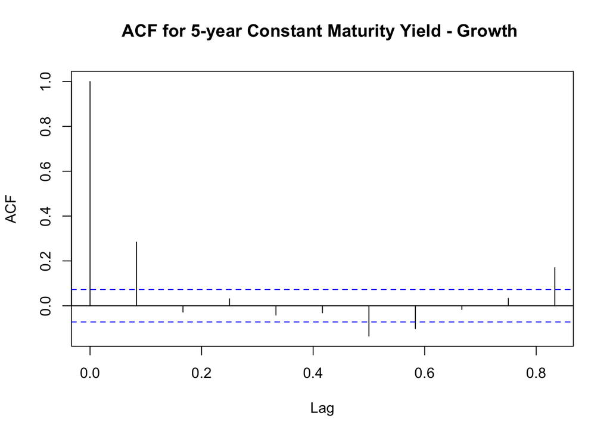

```r
acf(yield_growth_5Y,lag.max= 10, plot = TRUE, main = "ACF for 5-year Constant Maturity Yield - Growth ",na.action = na.pass)
```

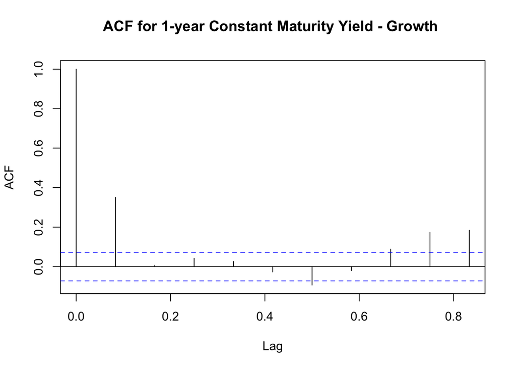

```r
acf(yield_growth_1Y,lag.max= 10, plot = TRUE, main = "ACF for 1-year Constant Maturity Yield - Growth ",na.action = na.pass)
```

```r
acf(yield_growth_10Y,lag.max= 10, plot =FALSE, main = "ACF for 10-year Constant Maturity Yield - Growth ",na.action = na.pass)
```

```
##
## Autocorrelations of series 'yield_growth_10Y', by lag
##
## 0.0000 0.0833 0.1667 0.2500 0.3333 0.4167 0.5000 0.5833 0.6667 0.7500 0.8333
##  1.000  0.270 -0.103  0.007 -0.008 -0.039 -0.089 -0.091 -0.017  0.067  0.121
```

```r
acf(yield_growth_5Y,lag.max= 10, plot = FALSE, main = "ACF for 5-year Constant Maturity Yield - Growth ",na.action = na.pass)
```

```
##
## Autocorrelations of series 'yield_growth_5Y', by lag
##
## 0.0000 0.0833 0.1667 0.2500 0.3333 0.4167 0.5000 0.5833 0.6667 0.7500 0.8333
##  1.000  0.284 -0.028  0.031 -0.042 -0.031 -0.135 -0.102 -0.017  0.033  0.170
```

```r
acf(yield_growth_1Y,lag.max= 10, plot = FALSE, main = "ACF for 1-year Constant Maturity Yield - Growth ",na.action = na.pass)
```

```
##
## Autocorrelations of series 'yield_growth_1Y', by lag
##
## 0.0000 0.0833 0.1667 0.2500 0.3333 0.4167 0.5000 0.5833 0.6667 0.7500 0.8333
##  1.000  0.351  0.007  0.042  0.026 -0.027 -0.094 -0.020  0.088  0.174  0.184
```

**Key findings:** All the ACF plots show 1 distinct spike indicating that we can use MA(1) process to estimate an MA model. For the 1-Year yield we see that the autocorrelation value at the first lag is higher as compared to 5-Year. And 5-year is higher as compared to 10-Year. 0.351 > 0.284 > 0.270. This means that for short duration maturity yields there is higher correlation between current period and the last period.

```r
model_10y<-arima(x=yield_growth_10Y,order=c(0,0,1))
model_10y
```

```
##
## Call:
## arima(x = yield_growth_10Y, order = c(0, 0, 1))
##
## Coefficients:
##          ma1  intercept
##       0.3974    -0.0712
## s.e.  0.0423     0.2463
##
## sigma^2 estimated as 19.56:  log likelihood = -1827.83,  aic = 3661.65
```

```r
model_5y<-arima(x=yield_growth_5Y,order=c(0,0,1))
model_5y
```

```
##
## Call:
## arima(x = yield_growth_5Y, order = c(0, 0, 1))
##
## Coefficients:
##          ma1  intercept
##       0.3625    -0.0510
## s.e.  0.0392     0.3041
##
## sigma^2 estimated as 36.6:  log likelihood = -2362.8,  aic = 4731.6
```

```r
model_1y<-arima(x=yield_growth_1Y,order=c(0,0,1))
model_1y
```

```
##
## Call:
## arima(x = yield_growth_1Y, order = c(0, 0, 1))
##
## Coefficients:
##          ma1  intercept
##       0.4236    -0.5444
## s.e.  0.0375     0.4287
##
## sigma^2 estimated as 57.09:  log likelihood = -2164.66,  aic = 4335.32
```